# Incarceration of Asian American in the U.S. from 1990 to 2016

Jimmy Cheong

2/23/2022

# Introduction

This project analysis incarceration trends in the U.S. to learn the situations/trends of incarceration of Asian American by comparing its trend to trend of incarceration of Whites. This report focuses on the count and rate of **Prison Population**, **Jail Population** of each races and compare their trends(*Prison/Jail Rate*, *Prison/Jail Rate Change*) against each other to learn the difference of incarceration trend by race.

To be specific, we would put our eyes on variables including:

`Population Count (Ages 15 to 64)`, `Jail Population Count`, and `Prison Population Count`

among *AAPI(Asian American/Pacific Islander)* and *Whites*.

However, this report only analysis data since 1990 to 2016 as data outside this period 1990 is mostly missing, incomplete, and were partly estimated.

### Summary Information

|  | AAPI | White |
| --- | --- | --- |
| Average_Prison_Popluation_Per_Year | 4071.07 | 332377.67 |
| Highest_Prison_Population_Rate_in_a_year | 0.06 % | 0.359 % |
| Lowest_Prison_Population_Rate_in_a_year | 0.002 % | 0.11 % |
| Highest_Jail_Population_Rate_in_a_year | 0.092 % | 0.265 % |
| Lowest_Jail_Population_Rate_in_a_year | 0.035 % | 0.134 % |
| Prison_percentage_increasement_since_1990 | 3889.091 % | 204.214 % |
| Jail_percentage_increasement_since_1990 | 244.698 % | 101.952 % |

# Trends over time chart

The following chart shows the percentage population of AAPI/WHITE in Prison/Jail. This shows the trend in population rate who got into prison and jail for every year from 1990 to 2016.

We could see that while both Prison/Jail population rate had increased over time for both races. The increasement of White is steeper while increasement of AAPI is has a relatively gentle slope.

For the design, I’ve picked a color blind friendly color pattern and matched two sets of colors to each of the race*(Orange for AAPI, Blue for White)*.

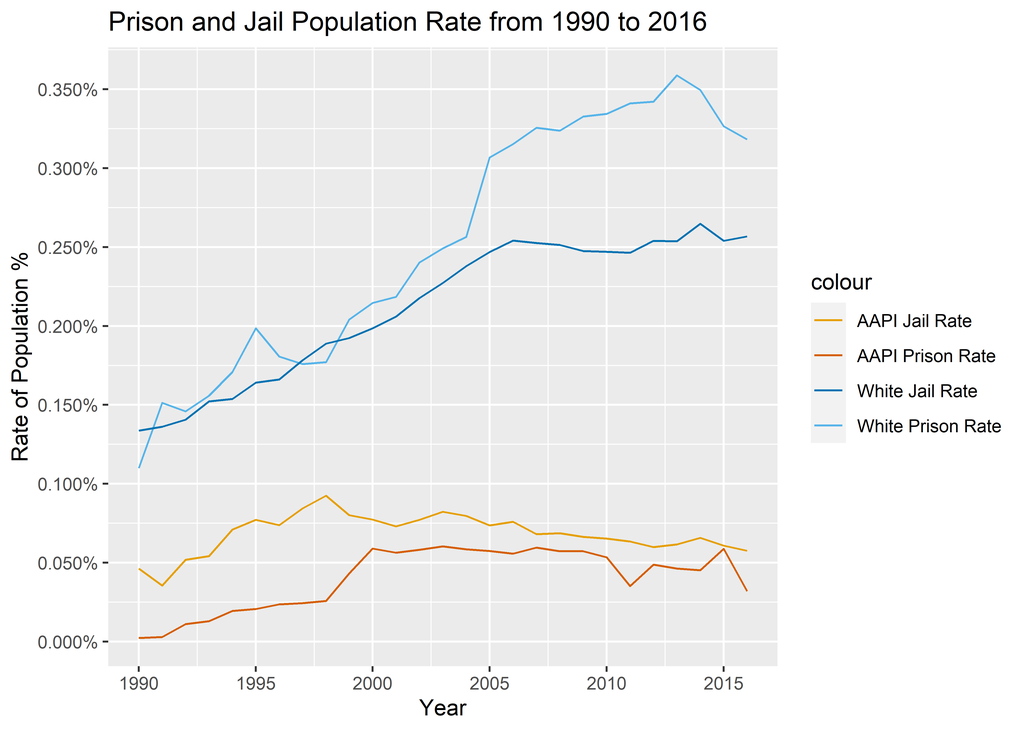

# Variable comparison chart

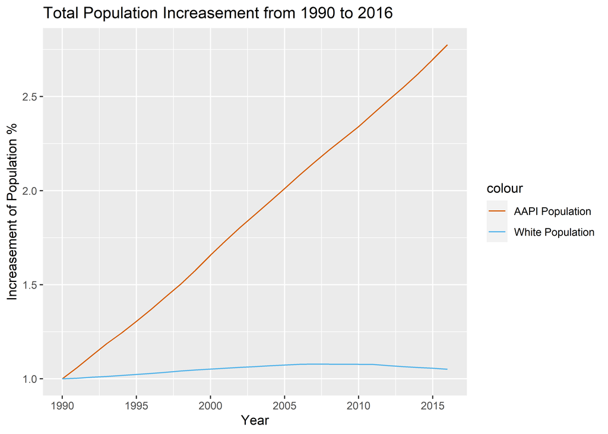

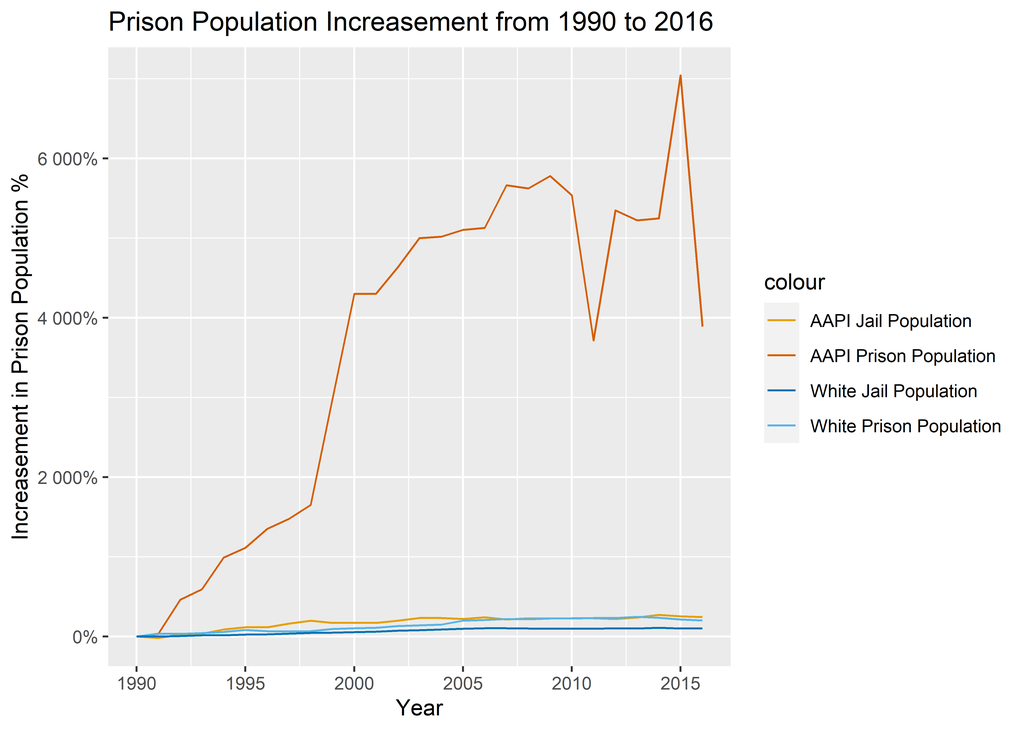

# Map

This map had shown the difference in average prison rate of AAPI and White for each county.

On The map was drawn by counties to help us spot specific counties which most bias on AAPI prison incarceration.

The more **red** the county shape, the **higher** the AAPI prison rate compare to White, vice versa.

We can see that there are a few county with absolute **red** *(biased toward White with higher AAPI prison rate)* on the east side of the U.S. and an absolute **no red** county *(biased toward AAPI with higher White prison rate)* near the center part.

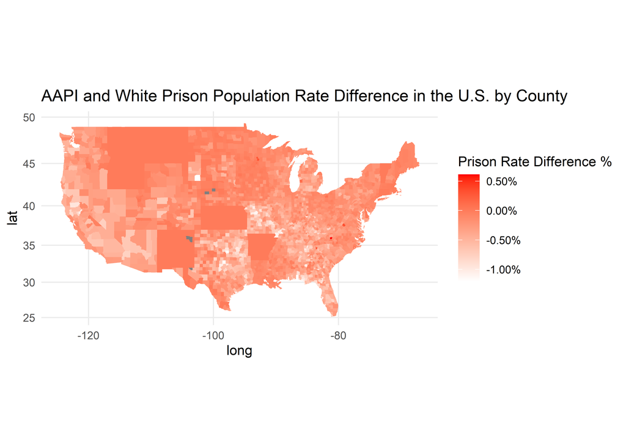